# Semantic Segmentation of Brain Tumor using Deep Neural Network – UNet

Anudeep Balagam

abalagam@buffalo.edu

50442091

## Content :

```
- Neural Networks:
    - Working of Neural Networks
    - Types of Neural Networks

- Convolution Neural Network:
    - Defination
    - Layers in CNN

- UNet:
    - Overview
    - Architecture
    - UNet Code
    - UNet Explanation

- Project Data

- Techniques Used

- Project Code

- Sample Image

- Models Used

- Model Results

- Final Results

- Conclusion
```

# Neural Networks

- Deep learning techniques are based on neural networks, sometimes referred to as artificial neural networks (ANNs) or simulated neural networks (SNNs), which are a subset of machine learning.
- Their structure and nomenclature are modeled after the human brain, mirroring the communication between organic neurons.
- A node layer of an artificial neural network (ANN) consists of an input layer, one or more hidden layers, and an output layer.
- Each node, or artificial neuron, is connected to others and has a weight and threshold that go along with it.
- Any node whose output exceeds the defined threshold value is activated and begins sending data to the network's uppermost layer. Otherwise, no data is transmitted to the network's next layer.

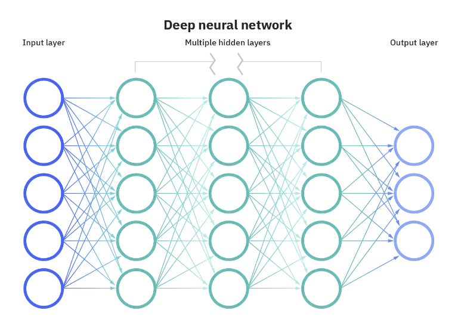

- Training data is essential for neural networks to develop and enhance their accuracy over time.
- However, these learning algorithms become effective tools in computer science and artificial intelligence once they are adjusted for accuracy, enabling us to quickly classify and cluster data.
- When compared to manual identification by human experts, tasks in speech recognition or picture recognition can be completed in minutes as opposed to hours.
- Google's search algorithm uses a neural network, one of the most well-known ones.

# Working of Neural Network

- Think of each individual node as its own linear regression model, composed of input data, weights, a bias (or threshold), and an output. The formula for this is:

  ```
    - ∑wixi + bias = w1x1 + w2x2 + w3x3 + bias

    - output = f(x) = 1 if ∑w1x1 + b>= 0; 0 if ∑w1x1 + b < 0
  ```

# Types of neural networks

- Diverse types of neural networks with different applications can be categorized. Although not an exhaustive list, the following would serve as an example of the most typical neural network types you'll see for its most typical use cases:
- The perceptron is the oldest neural network, created by Frank Rosenblatt in 1958. It has a single neuron and is the simplest form of a neural network:

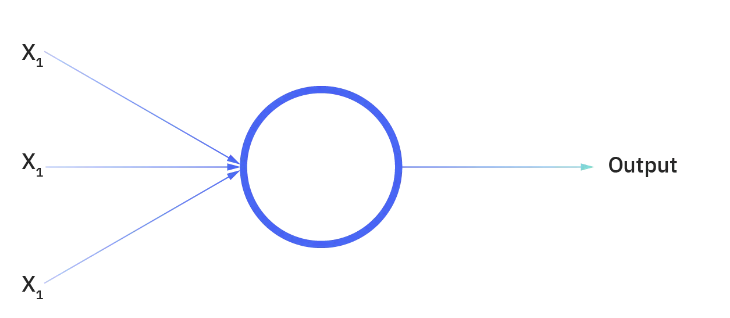

- We've mostly been concentrating on feedforward neural networks, or multi-layer perceptrons (MLPs), in this post.
- They consist of an output layer, one or more hidden layers, and an input layer.
- Because most real-world issues are nonlinear, sigmoid neurons, not perceptrons, are used in these neural networks, which are also sometimes referred to as MLPs.
- These models serve as the basis for neural networks used in computer vision, natural language processing, and other fields.
- Data is typically input into them to train them.
- Similar to feedforward networks, convolutional neural networks (CNNs) are used for image recognition, pattern identification, and/or computer vision. To find patterns in a picture, these networks use ideas from linear algebra, particularly matrix multiplication.
- Recurrent neural networks (RNNs) are identified by their feedback loops. These learning algorithms are primarily leveraged when using time-series data to make predictions about future outcomes, such as stock market predictions or sales forecasting.

# Convolution Neural Network :

- For this project I used one of the Convolution Neural Network Method
- A Convolutional Neural Network (ConvNet/CNN) is a Deep Learning algorithm that can take in an input image, give various aspects and objects in the image importance (learnable weights and biases), and be able to distinguish between them.

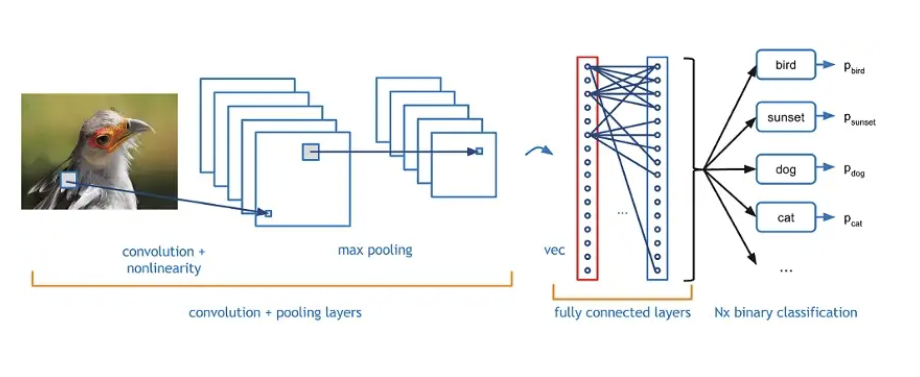

# Layers in CNN

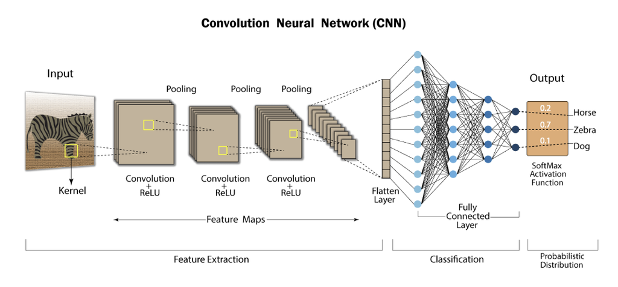

### Input Layer:

- Image data should be present in the input layer of CNN. As we previously saw, a three-dimensional matrix is used to represent image data.
- It must be transformed into a single column.
- If an image has the dimensions 28 x 28 = 784, it must first be converted to 784 x 1 before being fed into the input. When training with "m" samples, the dimension of the input will be (784, m).

### Convo Layer:

- Due to the fact that characteristics of the picture are extracted within this layer, this layer is also known as feature extractor layer.
- In order to perform convolution operations and calculate the dot product between the receptive field and the filter, a portion of the picture is first connected to the Convo layer.
- One integer representing the output volume is the operation's output.
- Then, via a Stride, we move the filter over the following receptive area of the identical input picture and repeat the process. Until we have completed the entire image, the same procedure will be repeated.
- The input for the following layer will be the output.
- Additionally, the Convo layer has ReLU activation to set all negative values to zero.

### Pooling Layer

It has two hyperparameters — Filter(F) and Stride(S).

In general, if we have input dimension W1 x H1 x D1, then

W2 = (W1−F)/S+1

H2 = (H1−F)/S+1

D2 = D1

Where W2, H2 and D2 are the width, height and depth of output.

### Fully Connected Layer

- There are neurons, weights, and biases in a fully linked layer. Neurons in one layer are linked to neurons in another layer through this. It is employed to train users to classify images into various categories.

### Softmax Layer

- The final layer of CNN is called Softmax or Logistic layer. It is located at the bottom of FC layer. Softmax is used for multi-classification, while logistic is used for binary classification.

### Output Layer

- Output layer contains the label which is in the form of one-hot encoded.

# UNet

- This is the algorithm I used for my project.

### Overview

UNet, which developed from the conventional convolutional neural network, was created and used for the first time in 2015 to process images used in biomedicine. A standard convolutional neural network focuses on classifying images, with an input of an image and an output of a single label. However, in biomedical applications, it is necessary to identify both the presence of a disease and the location of the abnormality.

### Architecture:

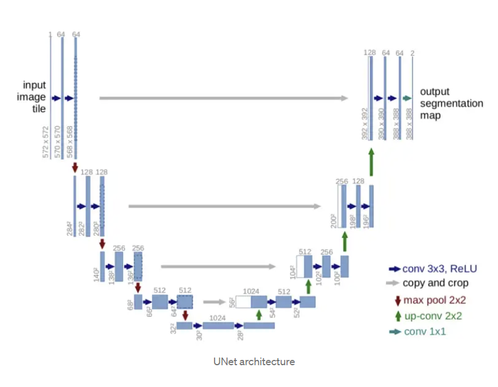

- It appears to be in the shape of a "U."
- The design is symmetrical and is divided into two main sections: the left section is known as the contracting path and is made up of the basic convolutional process; the right section is known as the expansive path and is made up of transposed 2D convolutional layers (you can think it as an upsampling technic for now).

# UNet Code

```python
def build_model(input_layer, start_neurons):
    conv1 = Conv2D(start_neurons * 1, (3, 3), activation="relu", padding="same")(input_layer)
    conv1 = Conv2D(start_neurons * 1, (3, 3), activation="relu", padding="same")(conv1)
    pool1 = MaxPooling2D((2, 2))(conv1)
    pool1 = Dropout(0.25)(pool1)

    conv2 = Conv2D(start_neurons * 2, (3, 3), activation="relu", padding="same")(pool1)
    conv2 = Conv2D(start_neurons * 2, (3, 3), activation="relu", padding="same")(conv2)
    pool2 = MaxPooling2D((2, 2))(conv2)
    pool2 = Dropout(0.5)(pool2)

    conv3 = Conv2D(start_neurons * 4, (3, 3), activation="relu", padding="same")(pool2)
    conv3 = Conv2D(start_neurons * 4, (3, 3), activation="relu", padding="same")(conv3)
    pool3 = MaxPooling2D((2, 2))(conv3)
    pool3 = Dropout(0.5)(pool3)

    conv4 = Conv2D(start_neurons * 8, (3, 3), activation="relu", padding="same")(pool3)
    conv4 = Conv2D(start_neurons * 8, (3, 3), activation="relu", padding="same")(conv4)
    pool4 = MaxPooling2D((2, 2))(conv4)
    pool4 = Dropout(0.5)(pool4)

    # Middle
    convm = Conv2D(start_neurons * 16, (3, 3), activation="relu", padding="same")(pool4)
    convm = Conv2D(start_neurons * 16, (3, 3), activation="relu", padding="same")(convm)

    deconv4 = Conv2DTranspose(start_neurons * 8, (3, 3), strides=(2, 2), padding="same")(convm)
    uconv4 = concatenate([deconv4, conv4])
    uconv4 = Dropout(0.5)(uconv4)
    uconv4 = Conv2D(start_neurons * 8, (3, 3), activation="relu", padding="same")(uconv4)
    uconv4 = Conv2D(start_neurons * 8, (3, 3), activation="relu", padding="same")(uconv4)

    deconv3 = Conv2DTranspose(start_neurons * 4, (3, 3), strides=(2, 2), padding="same")(uconv4)
    uconv3 = concatenate([deconv3, conv3])
    uconv3 = Dropout(0.5)(uconv3)
    uconv3 = Conv2D(start_neurons * 4, (3, 3), activation="relu", padding="same")(uconv3)
    uconv3 = Conv2D(start_neurons * 4, (3, 3), activation="relu", padding="same")(uconv3)

    deconv2 = Conv2DTranspose(start_neurons * 2, (3, 3), strides=(2, 2), padding="same")(uconv3)
    uconv2 = concatenate([deconv2, conv2])
    uconv2 = Dropout(0.5)(uconv2)
    uconv2 = Conv2D(start_neurons * 2, (3, 3), activation="relu", padding="same")(uconv2)
    uconv2 = Conv2D(start_neurons * 2, (3, 3), activation="relu", padding="same")(uconv2)

    deconv1 = Conv2DTranspose(start_neurons * 1, (3, 3), strides=(2, 2), padding="same")(uconv2)
    uconv1 = concatenate([deconv1, conv1])
    uconv1 = Dropout(0.5)(uconv1)
    uconv1 = Conv2D(start_neurons * 1, (3, 3), activation="relu", padding="same")(uconv1)
    uconv1 = Conv2D(start_neurons * 1, (3, 3), activation="relu", padding="same")(uconv1)

    output_layer = Conv2D(1, (1,1), padding="same", activation="sigmoid")(uconv1)

    return output_layer

input_layer = Input((img_size_target, img_size_target, 1))
output_layer = build_model(input_layer, 16)
```

# UNet - Explanation

### Contracting Path

- The contracting path follows the formula:

  ```
    - conv_layer1 -> conv_layer2 -> max_pooling -> dropout(optional)
  ```

```python
# the first part of the code is:

conv1 = Conv2D(start_neurons * 1, (3, 3), activation="relu", padding="same")(input_layer)
conv1 = Conv2D(start_neurons * 1, (3, 3), activation="relu", padding="same")(conv1)
pool1 = MaxPooling2D((2, 2))(conv1)
pool1 = Dropout(0.25)(pool1)
```

this code matches to:

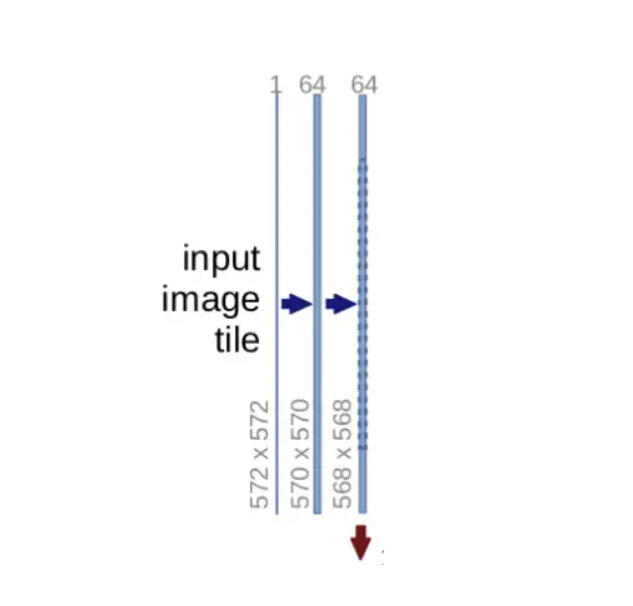

As the convolution process increases the depth of the image, you'll see that each step consists of two convolutional layers and that the number of channels changes from 1 to 64. The max pooling procedure, indicated by the red arrow pointing downward, reduces the size of the image by half (572x572 became 568x568 owing to padding difficulties, however this implementation uses padding="same").

This process is repeated 3 times:

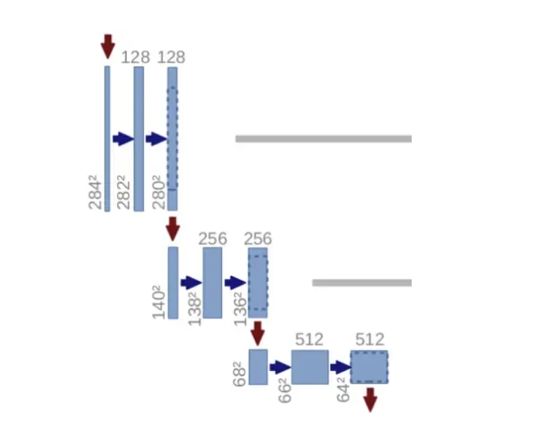

```python
#Code:

conv2 = Conv2D(start_neurons * 2, (3, 3), activation="relu", padding="same")(pool1)
conv2 = Conv2D(start_neurons * 2, (3, 3), activation="relu", padding="same")(conv2)
pool2 = MaxPooling2D((2, 2))(conv2)
pool2 = Dropout(0.5)(pool2)

conv3 = Conv2D(start_neurons * 4, (3, 3), activation="relu", padding="same")(pool2)
conv3 = Conv2D(start_neurons * 4, (3, 3), activation="relu", padding="same")(conv3)
pool3 = MaxPooling2D((2, 2))(conv3)
pool3 = Dropout(0.5)(pool3)

conv4 = Conv2D(start_neurons * 8, (3, 3), activation="relu", padding="same")(pool3)
conv4 = Conv2D(start_neurons * 8, (3, 3), activation="relu", padding="same")(conv4)
pool4 = MaxPooling2D((2, 2))(conv4)
pool4 = Dropout(0.5)(pool4)
```

the bottom most layer:

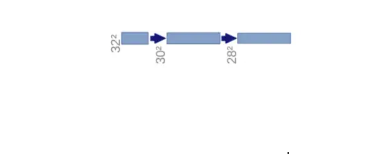

```python
# Middle
convm = Conv2D(start_neurons * 16, (3, 3), activation="relu", padding="same")(pool4)
convm = Conv2D(start_neurons * 16, (3, 3), activation="relu", padding="same")(convm)

#The image at this moment has been resized to 28x28x1024.
```

### Expansive Path

- In the expansive path, the image is going to be upsized to its original size. The formula follows:
  - conv_2d_transpose -> concatenate -> conv_layer1 -> conv_layer2

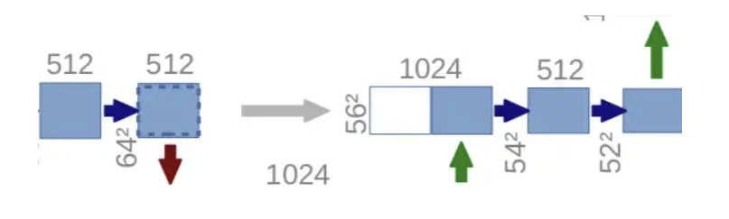

```python
deconv4 = Conv2DTranspose(start_neurons * 8, (3, 3), strides=(2, 2), padding="same")(convm)
uconv4 = concatenate([deconv4, conv4])
uconv4 = Dropout(0.5)(uconv4)
uconv4 = Conv2D(start_neurons * 8, (3, 3), activation="relu", padding="same")(uconv4)
uconv4 = Conv2D(start_neurons * 8, (3, 3), activation="relu", padding="same")(uconv4)
```

- Transposed convolution is an upsampling technic that expands the size of images.
- The picture is upsized from 28x28x1024 to 56x56x512 following the transposed convolution.
- This image is then concatenated with the comparable image from the contracting path, and the combined result is an image with the dimensions 56x56x1024.
- The information from the earlier layers is combined to produce a more accurate prediction.

```python
#this process is repeated 3 more times:

deconv3 = Conv2DTranspose(start_neurons * 4, (3, 3), strides=(2, 2), padding="same")(uconv4)
uconv3 = concatenate([deconv3, conv3])
uconv3 = Dropout(0.5)(uconv3)
uconv3 = Conv2D(start_neurons * 4, (3, 3), activation="relu", padding="same")(uconv3)
uconv3 = Conv2D(start_neurons * 4, (3, 3), activation="relu", padding="same")(uconv3)

deconv2 = Conv2DTranspose(start_neurons * 2, (3, 3), strides=(2, 2), padding="same")(uconv3)
uconv2 = concatenate([deconv2, conv2])
uconv2 = Dropout(0.5)(uconv2)
uconv2 = Conv2D(start_neurons * 2, (3, 3), activation="relu", padding="same")(uconv2)
uconv2 = Conv2D(start_neurons * 2, (3, 3), activation="relu", padding="same")(uconv2)

deconv1 = Conv2DTranspose(start_neurons * 1, (3, 3), strides=(2, 2), padding="same")(uconv2)
uconv1 = concatenate([deconv1, conv1])
uconv1 = Dropout(0.5)(uconv1)
uconv1 = Conv2D(start_neurons * 1, (3, 3), activation="relu", padding="same")(uconv1)
uconv1 = Conv2D(start_neurons * 1, (3, 3), activation="relu", padding="same")(uconv1)
```

- The last step is to reshape the image to satisfy our prediction requirements.

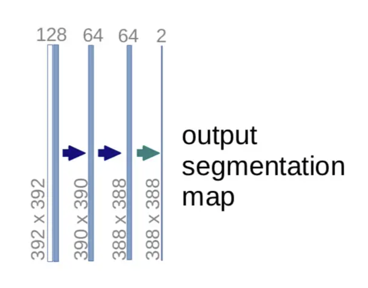

```python
output_layer = Conv2D(1, (1,1), padding="same", activation="sigmoid")(uconv1)

#The last layer is a convolution layer with 1 filter of size 1x1
```

# Project Data

The dataset link: https://www.kaggle.com/datasets/mateuszbuda/lgg-mri-segmentation .

The collection includes manual FLAIR abnormality segmentation masks and 3929 brain MRI images. These images correspond to 110 patients included in The Cancer Genome Atlas (TCGA) lower-grade glioma collection with at least fluid-attenuated inversion recovery (FLAIR) sequence and genomic cluster data which we will not using for this project. Also, some brain tumors are visible on brain MRIs while others are not. Each of the brain MRI images in the dataset is a 256 x 256 RGB image and each mask is a 256 x 256 Boolean matrix with each index indicating 1 or 0.

# Techniques Used - Semantic Segmentation

- Semantic image segmentation is the task of labelling each pixel of the image into a predefined set of classes.
- Machines can augment analysis performed by radiologists, greatly reducing the time required to run diagnositic tests.

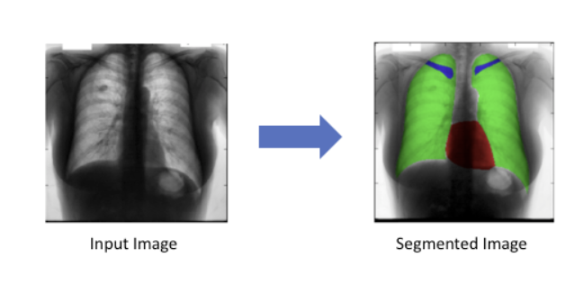

# Data Augmentation

- Data augmentation is a group of methods used to add extra data to a machine learning model, either in the form of newly generated synthetic data from existing data or copies of existing data that have been slightly altered. It lessens overfitting of the data and smooths out the machine learning model.

## Operations used for the project

- Flipping
- Rotation
- Shift
- Shear

# Project Code

```python
### Libraries Used:
import os
import numpy as np
import matplotlib.pyplot as plt
import cv2
import torch
import torch.nn as nn
import math
import seaborn as sns
from keras.preprocessing.image import ImageDataGenerator
import skimage.io as io
import glob
from skimage.transform import resize
from skimage.color import rgb2gray
from keras.callbacks import ModelCheckpoint
from keras import backend as K
from PIL import Image
from skimage.transform import resize
import numpy as np
from keras.optimizers import *
from keras.models import *
from keras.layers import *
from tqdm import tqdm
from google.colab import drive
import tensorflow as tf
from keras.layers import Input
import random
```

# Checking masks for each image

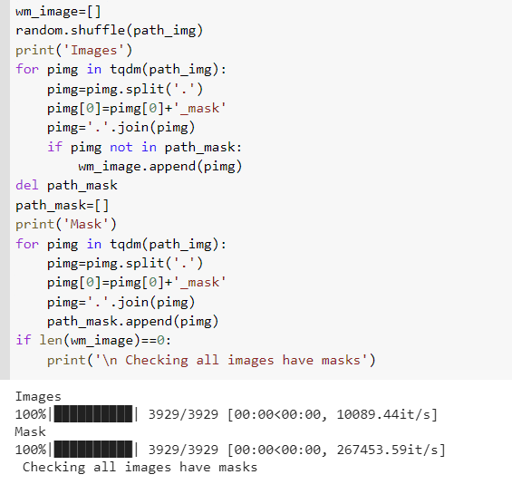

# Sample Image of the data

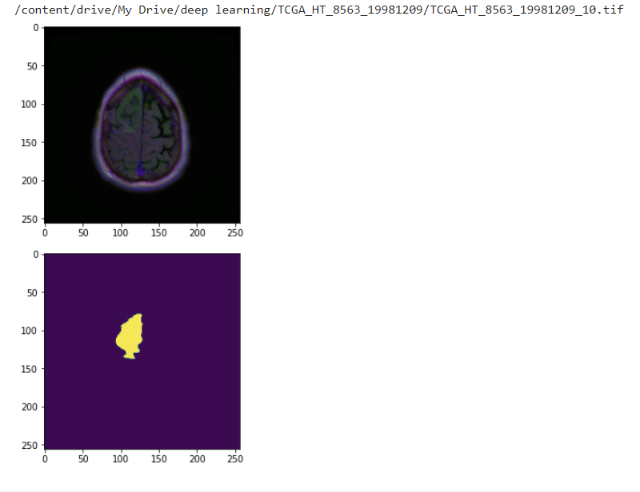

## Models used:

```
- IOU Loss
- Dice Loss
- Binary Cross Entropy Loss
```

### IOU Loss

- IoU loss is an option for unbalanced segmentation and has fewer hyperparameters than the others

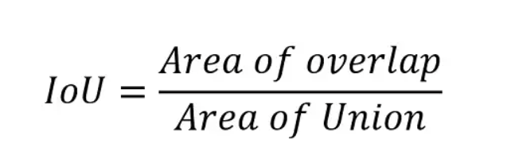

- In the equation, the nominator is the overlap between the predicted and ground-truth masks, and the denominator is the union of them.
- The IoU is calculated by dividing these two numbers, with values closer to one indicating more accurate predictions.

### Dice Loss

- Dice Loss is widely used in medical image segmentation tasks to address the data imbalance problem.

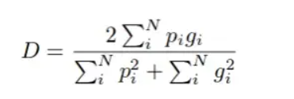

- Dice coefficient double counts the intersection(TP). Dice coefficient is a measure of overlap between two masks. 1 indicates a perfect overlap while 0 indicates no overlap.
- Dice Loss = 1 — Dice Coefficient

### Binary Cross Entropy Loss (BCE)

- Binary cross entropy compares each of the predicted probabilities to actual class output which can be either 0 or 1.
- It then calculates the score that penalizes the probabilities based on the distance from the expected value.
- That means how close or far from the actual value.

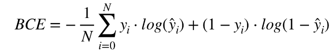

# Model Results:

## IOU Model

### IOU Loss Graph

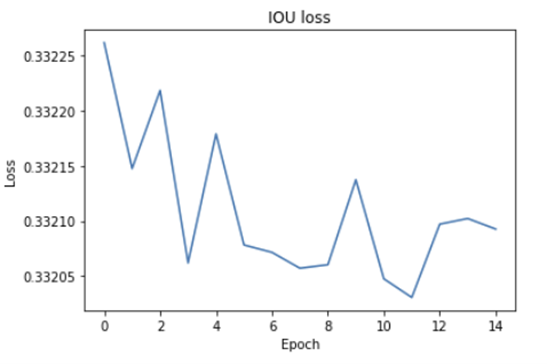

### Miou Graph

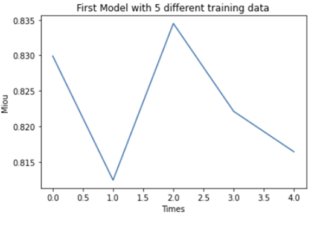

## Dice Model

### Dice Model Garph

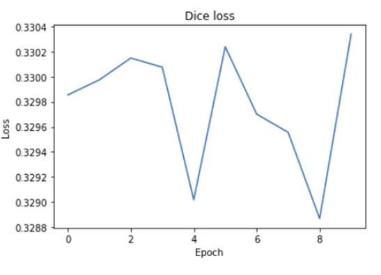

### Miou Graph

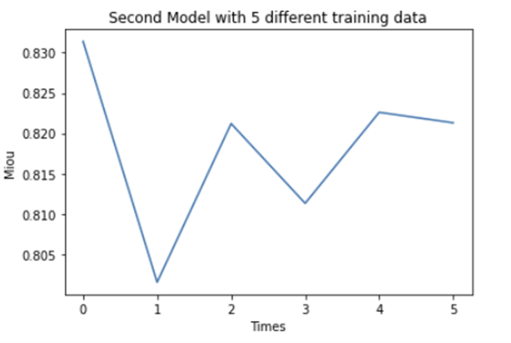

## BCE Model

### BCE Model Graph

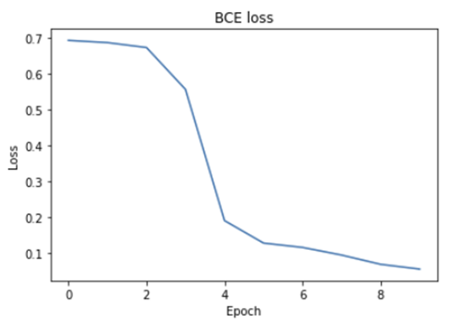

### Miou Graph

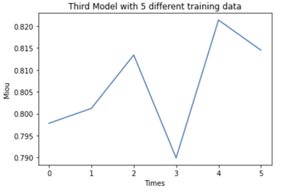

# Final Results

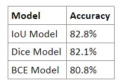

- From the table it is clear that IoU Model gives the best result for the data i took.

# Conclusion

- Based on the dataset I used which contains 3929 brain MR images with manual FLAIR abnormality segmentation mass, I enhanced the efficiency and accuracy to the segmentation.
- Among all the experiments I have done I observe that IOU Loss is better suited compared to Dice and BCE loss.
- I hope this experimentation gives a verification on tumor contouring and also, I hope this can be used for other medical analysis.